# Writing Documents in RMarkdown

Neal Marquez

February 21, 2019

# 1 R Markdown

R Markdown is a great way to not only inspect your data but also share your research with others who may not be as technically inclined as yourself. It should be seen as a tool that streamlines the process between analysis and dissemination of your work.

Building Nice tables is easy using the knitr package and the kable function. We can make tables as shown in the rmarkdown chunk as shown below and refernce a figure by using a comand like “@ref(tab:table1)” to refernce table 1.1. Note that we use the abbreviation tab for table, fig for plots and figures and eq for equations.

```r
stargazer(cars, title = "My table",
          align=TRUE, header = F,
          type = ifelse(knitr::is_latex_output(),"latex","html"),
          label = knitr::opts_current$get("label"))
```

Table 1.1: **My table**

| Statistic | N | Mean | St. Dev. | Min | Pctl(25) | Pctl(75) | Max |
| --- | --- | --- | --- | --- | --- | --- | --- |
| speed | 50 | 15.400 | 5.288 | 4 | 12 | 19 | 25 |
| dist | 50 | 42.980 | 25.769 | 2 | 26 | 56 | 120 |

Table 1.2: **My table 2**

| Statistic | N | Mean | St. Dev. | Min | Pctl(25) | Pctl(75) | Max |
| --- | --- | --- | --- | --- | --- | --- | --- |
| Sepal.Length | 150 | 5.843 | 0.828 | 4.300 | 5.100 | 6.400 | 7.900 |
| Sepal.Width | 150 | 3.057 | 0.436 | 2.000 | 2.800 | 3.300 | 4.400 |
| Petal.Length | 150 | 3.758 | 1.765 | 1.000 | 1.600 | 5.100 | 6.900 |
| Petal.Width | 150 | 1.199 | 0.762 | 0.100 | 0.300 | 1.800 | 2.500 |

## 1.1 Regression Tables

For more complicated tables created using other packages or from your own latex or markdown we can add in label references by hand. Here we refernce a regression table using a modified version of the stargazer package Table 1.3.

Table 1.3: **Results**

|  | *Dependent variable:* |  |  |
| --- | --- | --- | --- |
|  | rating |  | high.rating |
|  | *OLS* |  | *probit* |
|  | (1) | (2) | (3) |
| complaints | 0.692*** | 0.682*** |  |
|  | (0.149) | (0.129) |  |
| privileges | -0.104 | -0.103 |  |
|  | (0.135) | (0.129) |  |
| learning | 0.249 | 0.238* | 0.164*** |
|  | (0.160) | (0.139) | (0.053) |
| raises | -0.033 |  |  |
|  | (0.202) |  |  |
| critical | 0.015 |  | -0.001 |
|  | (0.147) |  | (0.044) |
| advance |  |  | -0.062 |
|  |  |  | (0.042) |
| Constant | 11.011 | 11.258 | -7.476** |
|  | (11.704) | (7.318) | (3.570) |
| Observations | 30 | 30 | 30 |
| R<sup>2</sup> | 0.715 | 0.715 |  |
| Adjusted R<sup>2</sup> | 0.656 | 0.682 |  |
| Log Likelihood |  |  | -9.087 |
| Akaike Inf. Crit. |  |  | 26.175 |
| Residual Std. Error | 7.139 (df = 24) | 6.863 (df = 26) |  |
| F Statistic | 12.063*** (df = 5; 24) | 21.743*** (df = 3; 26) |  |
| *Note:* | p<0.1; p<0.05; p<0.01 |  |  |

# 2 Including Plots

You can also embed plots, and refrence them too! See Figure 2.1.

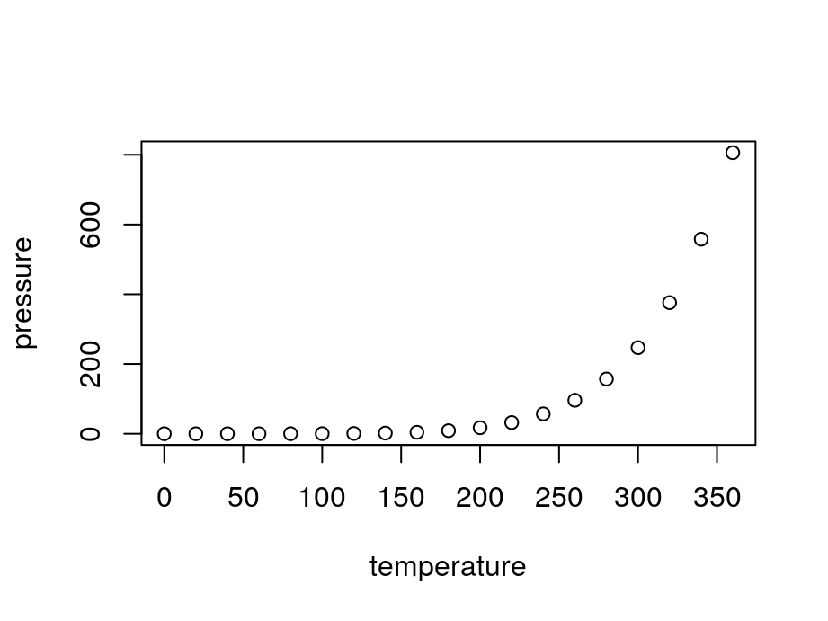

Figure 2.1: Exponential Growth

Same for Equation (2.1)

$$\begin{equation}
Y = \text{exp}(\beta_0 + \beta_1 X)
\tag{2.1}
\end{equation}$$

External figures are a little harder to format but still doable like in Figure 2.2.

[figure not shown]